# Praca domowa 2

## Dane

Dane wykorzystane w Pracy domowej 2 są związane z kampaniami marketingu bezpośredniego portugalskiej instytucji bankowej. Kampanie marketingowe opierały się na rozmowach telefonicznych. Często wymagany był więcej niż jeden kontakt z tym samym klientem, aby uzyskać dostęp do tego, czy produkt (lokata bankowa) zostanie (lub nie) subskrybowany. Opis wszystkich kolumn znajduje się również w pliku `README.md`.

#### Dane klienta banku

| Zmienna | Opis |
| --- | --- |
| **age** | wiek |
| **job** : admin., unknown, unemployed, management, housemaid, entrepreneur, student, blue-collar, self-employed, retired, technician, services | administrator, nieznany, bezrobotny, kierownictwo, pokojówka, przedsiębiorca, student, pracownik fizyczny, samozatrudniony, emeryt, technik, usługi |
| **marital** : married, divorced, single; note: divorced means divorced or widowed) | żonaty/zamężna, rozwiedzion_, kawaler/panna; uwaga: rozwiedzion_ oznacza rozwiedzion_ lub owdowiał_ |
| **education** : unknown, secondary, primary, tertiary | nieznane, średnie, podstawowe, wyższe |
| **default** : yes, no | czy kredyt jest niespłacany : tak, nie |
| **balance** : average yearly balance, in euros | średnie roczne saldo w euro |
| **housing** : has housing loan? yes, no | czy posiada kredyt mieszkaniowy? tak, nie |
| **loan** : has personal loan? yes, no | ma pożyczkę osobistą? tak, nie |

#### Dane związane z ostatnim kontaktem w bieżącej kampanii

| Zmienna | Opis |
| --- | --- |
| **contact** : unknown, telephone, cellular | nieznany, telefon, komórkowy |
| **day** : last contact day of the month | dzień miesiąca ostatniego kontaktu |
| **month** : last contact month of year, jan, feb, mar, …, nov, dec | miesiąc ostatniego kontaktu w roku, styczeń, luty, marzec, …, listopad, grudzień |
| **duration** : last contact duration, in seconds | czas trwania ostatniego kontaktu w sekundach |

## Zadanie 1 OK

Weźmy pod uwagę zawody (`job`) klientów banku. Który zawód zacząco wyróżnia się w posiadaniu kredytu mieszkaniowego lub pożyczki osobistej?

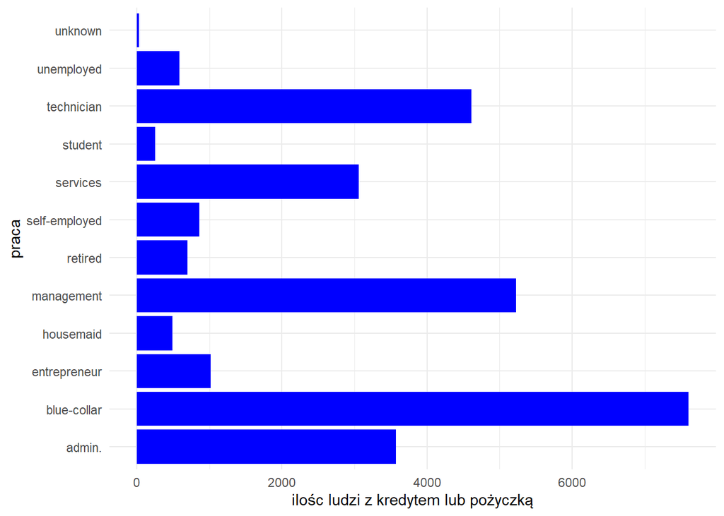

```r
df %>%
  filter(housing == "yes" | loan == "yes") %>%
  ggplot(aes(y = job))+
  geom_bar(fill = "blue")+
  theme_minimal()+
  labs(y = "praca", x = "ilośc ludzi z kredytem lub pożyczką")
```

**Komentarz:** Wyróżnia sie pod tym względem zawód blue-collar z łączną liczbą około 7500 pożyczek osobistych i kredytów mieszkaniowych.

## Zadanie 2 OK

Wybierając klientów, którzy mają nieznany sposób kontaktu (`contact`). Jak rozkłada się ich wiek w podziale na status związku?

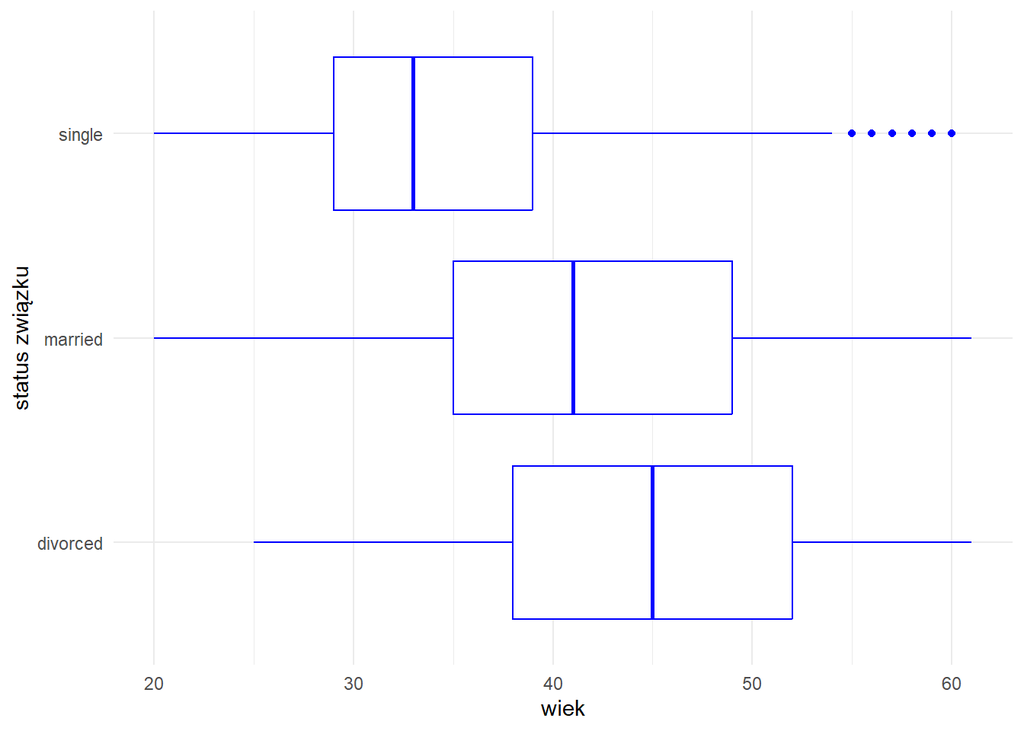

```r
df %>%
  filter(contact == "unknown") %>%
  ggplot(aes(y = marital,x = age)) +
  geom_boxplot(color = "blue")+
  theme_minimal()+
  labs(y = "status związku", x = "wiek")
```

**Komentarz:** Wiek osób, które są singlami, oscyluje w przedziale 20-54 lata. Powyżej jest jedynie kilka przypadków, które są outliarami. W znaczenej części są to osoby w wieku 29-39 lat i medianą wieku 33 lata. ósoby będące w małżeństwie znajdują się na całym przedziale wiekowym 20-61 , ale najbardziej skoncentrowani są na przedziale 35-49, z medianą 41. Osoby rozwiedzione można znaleźć na przedziale 25-61 z medianą 45. Najbardziej skoncentrowani są na przedziale 38-52.

## Zadanie 3 OK

Jaka jest różnica pomiędzy średnim rocznym saldem w euro w zależności od wykształcenia i tego czy kredyt jest niespłacany?

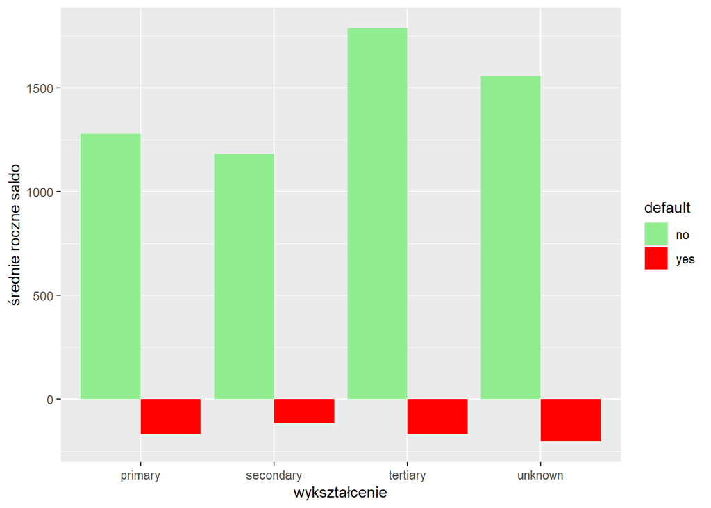

```r
df %>%
  group_by(education, default) %>%
  summarise(mean_bal = mean(balance)) %>%
  ggplot(aes(x = education, y = mean_bal, fill = default)) +
  geom_col(position = "dodge") +
  scale_fill_manual(values = c("lightgreen","red"))+
  labs(x = "wykształcenie", y = "średnie roczne saldo")
```

**Komentarz:** Widzimy, że różnica pomiędzy osobami płacącymi kredyt, a tymi, które go nie płacą jest znacząca i różni się w zależności od wykształcenia. Wynosi ona co najmniej około 1300 euro. Największa różnica jest w przypadku osób z wykształceniem wyższym, u których saldo jest wyższe o około 1900 euro względem osób, które spłacają, a tymi, które nie spłacają. ROżnica ta wynosi około 1700 euro dla osób o wykształceniu nieznanym, około 1300 euro dla osób o wykształceniu średnim oraz około 1400 euro dla osób z wykształceniem niższym.

## Zadanie 4 OK

Czy dzień i miesiąc kontaktu z klientem ma wpływ na średni czas trwania rozmowy w stosunku do średniego czasu trwania rozmowy?

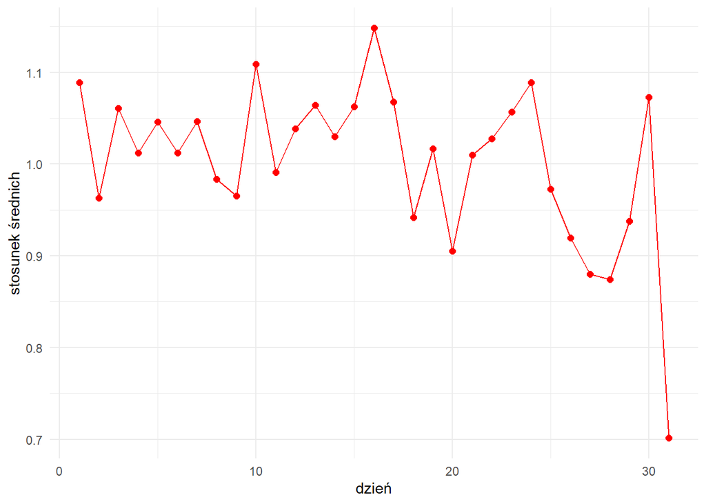

```r
avg <- mean(df$duration)

df %>%
  group_by(day) %>%
  summarise(mean_time_per_day = mean(duration)) %>%
  mutate(mean = mean_time_per_day / avg) %>%
  ggplot(aes(x = day, y = mean)) +
  geom_point(color = "red", size = 2) +
  geom_path(aes(y = mean), color = "red",group = 1) +
  theme_minimal()+
  labs(x = "dzień", y = "stosunek średnich")
```

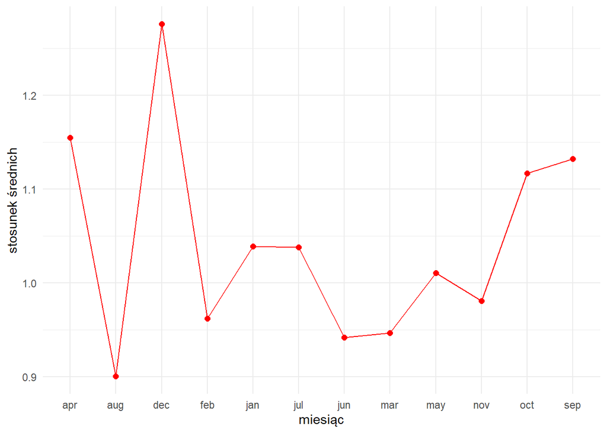

```r
avg <- mean(df$duration)

df %>%
  group_by(month) %>%
  summarise(mean_time_per_month = mean(duration)) %>%
  mutate(mean = mean_time_per_month / avg) %>%
  ggplot(aes(x = month, y = mean)) +
  geom_point(color = "red", size = 2) +
  geom_path(aes(y = mean), color = "red",group = 1) +
  theme_minimal()+
  labs(x = "miesiąc", y = "stosunek średnich")
```

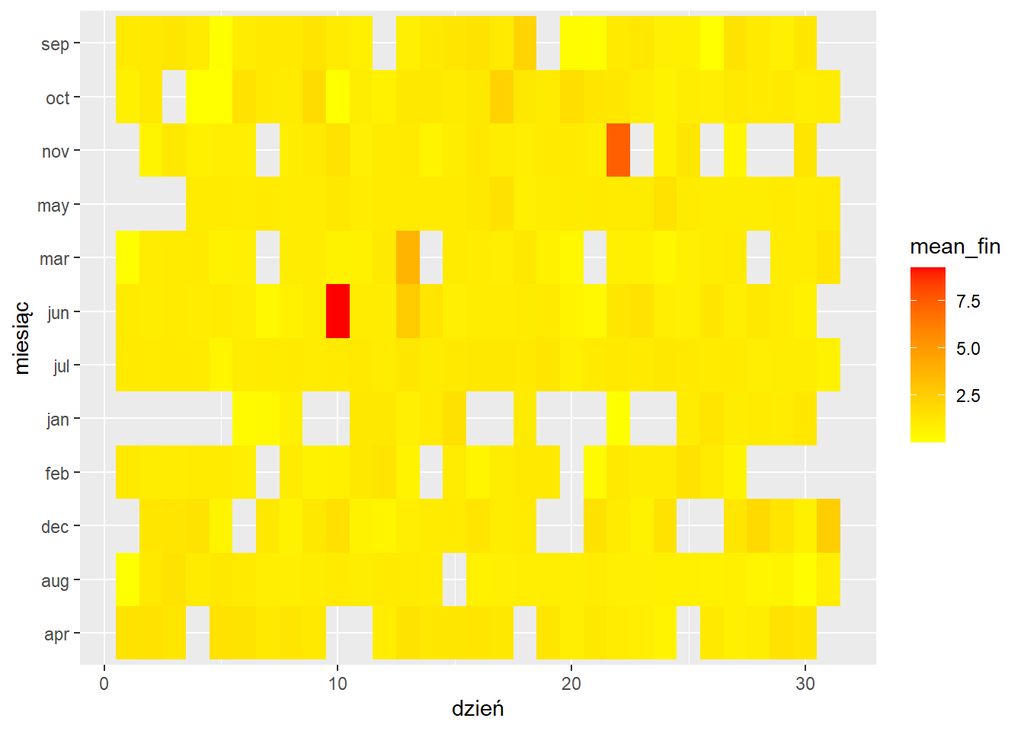

```r
avg <- mean(df$duration)

df %>%
  group_by(month, day) %>%
  summarise(mean1 = mean(duration)) %>%
  mutate(mean_fin = mean1 /avg) %>%
  ggplot(aes(x = day,y = month, fill = mean_fin)) +
  geom_tile() +
  scale_fill_gradient(low = "yellow", high = "red")+
  labs(x = "dzień", y = "miesiąc")
```

**Komentarz:** Jeżeli chodzi o zależność od dni to widzimy, że najmniejszy stosunek średnich notujemy 31 dnia miesiąca i wynosi około 0,7. Może to wynikać z tego, iż nie każdy miesiąc ma 31 dni stąd taka rozbieżność względem średnich z pozostałych dni. Największy stosunek średnich notowany jest natomiast 16 dni miesiąca i wynosi średnio prawie 1,15. Warto zauważyć że 30 dnia następuje skok. Najmniejszą wartość śreodniego czasu w odniesieniu do miesięcy zanotowano w sierpniu, czyli około 0,9, a największy w grudniu i wynosił około lekko ponad 1,28. Jeżeli chodzi o stosunek łaćznie to największy jest on 10czerwca i wynosi około 9.

## Zadanie 5 OK

Czy jest zależnośc pomiędzy wiekiem klientów a ich średnim rocznym saldzie w euro w podziale na stopień wykształcenia?

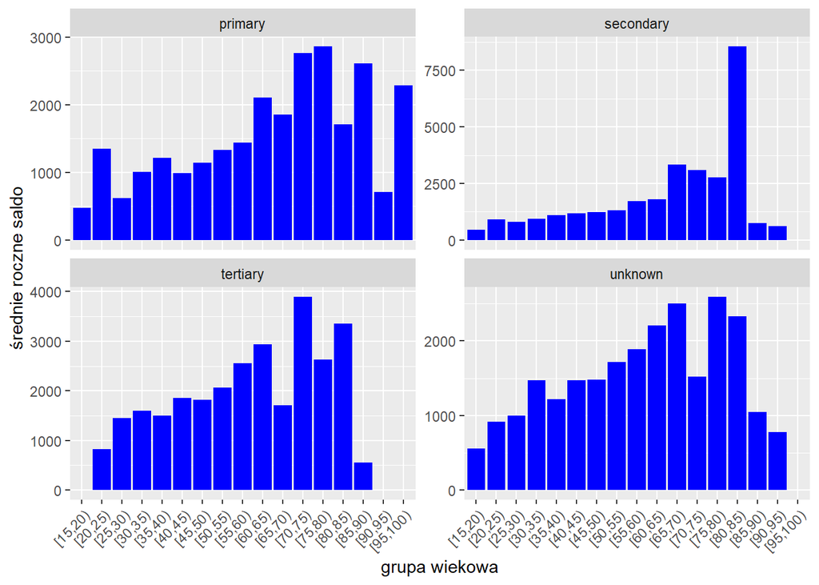

```r
df %>%
  mutate(grupa_wiekowa = cut(age, breaks = seq(10, 100, by = 5), right = FALSE,
                             labels = paste0("[",seq(10,95,by=5),",",seq(15, 100, by=5),")"))) %>%
  group_by(grupa_wiekowa, education) %>%
  summarise(mean_balance = mean(balance)) %>%
  ggplot(aes(x = grupa_wiekowa, y = mean_balance)) +
  geom_col(fill = "blue") +
  facet_wrap(~education, scales = "free_y") +
  theme(axis.text.x = element_text(angle = 45, hjust = 1))+
  labs(x = "grupa wiekowa", y = "średnie roczne saldo")
```

## Zadanie 6 OK

Rozważmy osoby, które są bezrobotne albo ich zawód jest nieznany. Czy procent osób, które są bezrobotne i nie spłacają kredytu jest większy od procenta osób o nieznanym zawodzie i nie spłacanym kredycie? Jaki typ kredytu jest (przez te osoby) najczęściej niespłacany?

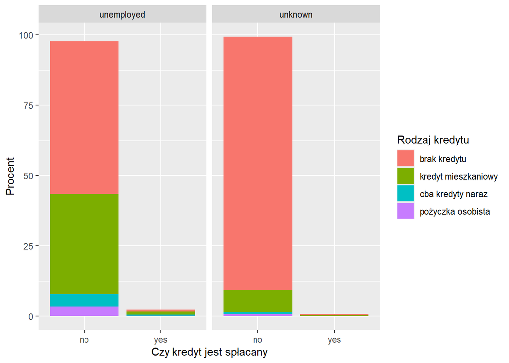

```r
total_unknown <- df %>%
  filter(job == "unknown") %>%
  nrow()
total_unemployed <- df %>%
  filter(job == "unemployed") %>%
  nrow()

df %>%
  filter(job %in% c("unknown","unemployed")) %>%
  select(job, default, housing, loan) %>%
  group_by(job, default, housing, loan) %>%
  summarise(count = n()) %>%
  mutate(credit = case_when(housing == "no" & loan == "no" ~ "brak kredytu",
                            housing == "yes" & loan == "no" ~ "kredyt mieszkaniowy",
                            housing == "no" & loan == "yes" ~ "pożyczka osobista",
                            housing == "yes" & loan == "yes" ~ "oba kredyty naraz")) %>%
  mutate(percentage = case_when(job == "unknown" ~ (count/total_unknown)*100,
                                job == "unemployed" ~ (count/total_unemployed)*100)) %>%
  ggplot(aes(x = default, y = percentage, fill = credit)) +
  geom_col()+
  facet_wrap(~job, scales = "free_x")+
  labs(x = "Czy kredyt jest spłacany", y = "Procent", fill = "Rodzaj kredytu")
```

**Komentarz:** Większy jest procent osób bezrobotnych, które kredytu nie spłacają, niż procent osób o zawodzie nieznanym, które nie spłacają. Typem kredytu najczęściej niespłacanym przez bezrobotnych jest kredyt mieszkaniowy, a w przypadku osób o nieznanym zawodzie jest to również kredyt mieszkaniowy.